# Data 608 Final Project Proposal

Joshua Registe

03/22/2020

# 1 Proposal

As part of this final project, I will be looking at emission patterns nationally over the past decade looking at potential major contributors to the cause of global warming. Engineers and scientists often get posed questions along the lines of infrastructure resiliency and protection against the effects of storms, rising sea level, air quality and water resources, all which are increasingly seeing the effects of climate change. It is important to understand his and be able to propose solutions that are feasible for the future of the planet.

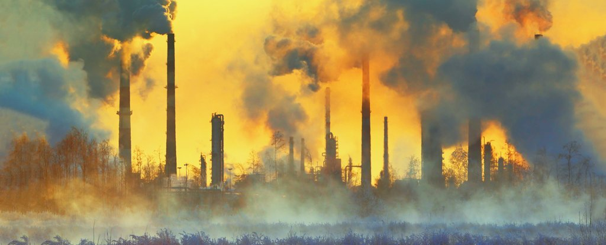

Some of the data sources that will be considered include:

US Energy Information governmental website has emissions data characterized by sector, state, and fuel source from the years 2005 to 2016 which can give us a handle on our biggest emitting states, sectors etc.

data source:  
https://www.eia.gov/environment/emissions/state/analysis/

I would like to create an interactive figure that would allow someone to look at carbon emissions by state, by type of emission and drilldown via different facets of data. This data should allow people to understand which states our biggest carbon emissions are from and what is the main source of that pollution.